# Localización de objetos

**Objetivo**: Aprender a localizar objetos mediante su color en imágenes simples.

**Conocimientos previos**: Conceptos básicos de imágenes digitales color y escala de grises. Programación en Python con la librería Numpy. Lectura, visualización y manipulación de imágenes con Numpy, PyPlot y skimage.

**Importante**: Para que este cuaderno funcione correctamente, las imágenes 'guante.png' y 'guante_zoom.png' deben estar en el mismo directorio que este cuaderno.

En este tutorial veremos una forma sencilla de localizar un objeto en una imagen. Para eso, vamos a realizar dos asunciones sobre el objeto:

- Tiene un color relativamente uniforme en toda su superficie
- Es el único objeto con ese color en la imagen.

En este caso, vamos a intentar encontrar el guante rojo de la persona en la imagen:

[figure not shown]

Nuestro objetivo entonces es obtener las coordenadas $(x,y)$ del guante.

La idea principal del método es encontar los píxeles que tengan el color del guante.

Algunos pixeles que no son del guante también serán encontrados; llamaremos a estos pixeles *ruido*. Luego, eliminaremos el ruido.

Por último, podemos encontrar el centro de los pixels que tienen ese color, o sea, del guante.

Comenzaremos cargando varias librerías que luego nos serán útiles. Luego cargaremos la imagen y veremos las distintas operaciones necesarias para encontrar el objeto.

```python
# comando de Jupyter para que las imagenes se muestren automaticamente
%matplotlib inline

#numpy es la libreria de arreglos de python (la llamaremos np)
import numpy as np

# el modulo pyplot de matplotlib (que llamaremos plt) nos permite mostrar imagenes
import matplotlib.pyplot as plt
#el modulo matplotlib.colors nos permite transformar el espacio de color de una imagen
import matplotlib.colors
# el mapa de color para las imágenes escala de grises es el gris
plt.rcParams['image.cmap'] = 'gray'


#el modulo io de skimage sirve para cargar y guardar imagenes
from skimage import io
```

Luego, cargamos la imagen y la mostramos para verificar que se cargó correctamente.

```
Dimensiones de la imagen: (1080, 1920, 3)
Tipo de los elementos de la imagen: float64
```

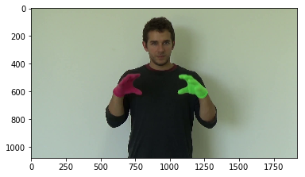

```python
# leemos la imagen desde un archivo, y la almacenamos en memoria en un arreglo
image = io.imread('guante.png')

# Convertimos la imagen de entero a flotante, y además convertimos el rango de los pixeles
# de 0-255 (entero) al rango 0-1 (flotante)
image=image/255.

#imprimimos las tres dimensiones del arreglo: las dos primeras corresponden al alto y ancho,
#la última a los canales de color (3 canales, por defecto RGB)
print("Dimensiones de la imagen: %s" % str(image.shape))

#guardamos las dimensiones en tres variables para usar en las celdas más abajo
h,w,c=image.shape

#mostramos el tipo de los elementos del arreglo (debería ser flotante!)
print("Tipo de los elementos de la imagen: %s" % str(image.dtype))

#visualizamos la imagen
plt.imshow(image)
```

## Filtrado por color

Una manera simple de reconocer un objeto es mediante su color. Si ese color es muy distintivo y uniforme (las asunciones que mencionamos arriba), podemos recorrer la imagen para encontrar los pixeles de ese color.

Enfoquémosnos en el guante:

[figure not shown]

Como se puede ver no hay *un* solo rojo sino varios, por variaciones de la iluminación y la textura de la remera.

Entonces, en lugar de buscar *un* color en particular, vamos a tener que buscar un rango de colores. Pero esto va a resultar difícil con el espacio de color RGB.

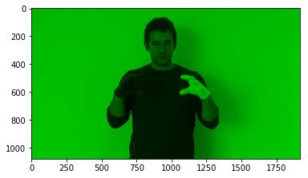

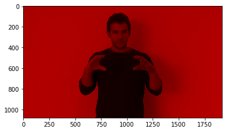

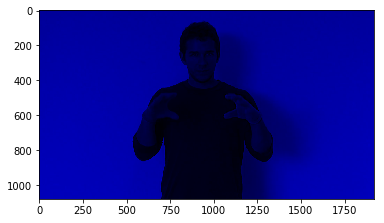

```python
#Vemos los canales individuales de RGB.
#El fondo blanco activa los 4 canales (R,G y B)
# El buzo y el pelo, al ser negro oscuro, no se activan en ningún canal
# Por otro lado, el guante rojo se activa en el canal rojo y no en los otros dos
# Y el guante verde se activa en los canales verde (mayormente) y azul

#Anulo los canales rojo y azul para ver solo el verde
green=np.copy(image)
green[:,:,0]=0
green[:,:,2]=0
plt.figure()
plt.imshow(green)

#Anulo los canales azul y verde para ver solo el rojo
red=np.copy(image)
red[:,:,1:3]=0
plt.figure()
plt.imshow(red)

#Anulo los canales rojo y verde para ver solo el azul
blue=np.copy(image)
blue[:,:,0:2]=0
plt.figure()
plt.imshow(blue)
```

## Conversión al espacio de colores HSV

En lugar de eso vamos a convertir los píxeles desde el espacio RGB al espacio HSV, en donde cada píxel se codifica también con tres valores, pero ahora con significado diferente:

- El canal H indica el tono (hue) del color (verde, rojo, azul, amarillo, etc).
  - El tono es lo que tradicionalmente entendemos como "color".
- El canal S indica la saturación (saturation) de color
  - Si un color es más saturado, es más "puro"
  - Si es menos saturado, tiene más "gris"
- El canal V indica la luminosidad o intensidad (value) del pixel.
  - V=0 indica un pixel negro
  - V=1 indica un pixel blanco

La función `rgb_to_hsv` del módulo `matplotlib.colors`nos permite hacer justamente eso.

```python
# Convertir a modelo HSV
image_hsv=matplotlib.colors.rgb_to_hsv(image)

print("El pixel de la posición (100,100) se codifica en RGB como %s " % str(image[100,100,:]))
print("El pixel de la posición (100,100) se codifica en HSV como %s " % str(image_hsv[100,100,:]))
```

```
El pixel de la posición (100,100) se codifica en RGB como [ 0.6627451   0.71372549  0.61568627]
El pixel de la posición (100,100) se codifica en HSV como [ 0.25333333  0.13736264  0.71372549]
```

Ahora miremos los canales HSV por separado

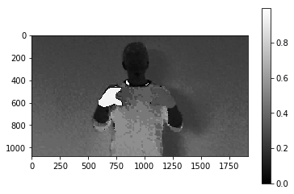

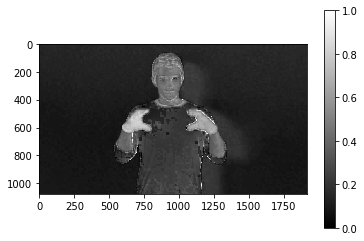

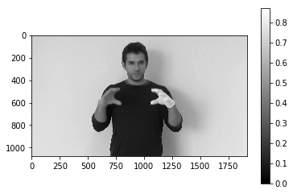

```python
#Vemos los canales individuales de HSV.

plt.figure()
plt.imshow(image_hsv[:,:,0])
plt.colorbar()

plt.figure()
plt.imshow(image_hsv[:,:,1])
plt.colorbar()

plt.figure()
plt.imshow(image_hsv[:,:,2])
plt.colorbar()
```

## Filtrando por color

Para filtrar por color, debemos averiguar el rango de colores del guante. Para ello, una forma sencilla consiste en abrir la imagen en un editor de imágenes que permita ver el valor de cada pixel, y anotar los valores de varios pixeles del guante. En este caso lo hicimos con el programa **Paint** y obtuvimos:

- $(H,S,V)$
- $(245,142,61)$
- $(242,201,119)$
- $(246,192,103)$
- $(245,219,153)$
- $(241,180,139)$
- $(238,117,72)$

Entonces el rango de colores que buscamos es, aproximadamente:

Como podemos observar, el canal H es el que mostró menos variación,ya que el tono se mantiene bastante constante. Por otro lado, el S y el V pueden variar mucho de acuerdo a la iluminación.

Para dar un poco más de rango, vamos a expandir un poco estos

- H entre $230$ y $250$.
- S entre $100$ y $230$.
- V entre $50$ y $170$.

Por otro lado, el programa **Paint** así como otros editores de imágenes nos dan estos valores codificados en los rangos 0-255 para H, V y S, por lo que habría que convertirlos a los intervalos 0-1 que utiliza numpy dividiendo por el extremo del rango, es decir:

```python
#Rango de colores a utilizar

#guante rojo
h_min,h_max=(230/255,250/255)
s_min,s_max=(100/255,230/255)
v_min,v_max=(50/255,170/255)
```

### Generación de la máscara de segmentación

En base a la imagen original y estos rangos de color, vamos a generar otra imagen llamada la *máscara de segmentación*. Esta máscara es simplemente una imagen en blanco y negro (cada pixel tiene valor $0$ o $1$). Si el pixel $i,j$ de la imagen original está en el rango de color, en la máscara el pixel $i,j$ tendra el valor $1$. Si no, tendra valor $0$. Entonces, a partir de la imagen de la izquierda codificada en HSV, generaremos mascara de segmentación (otra imagen, pero en blanco y negro) de la derecha:

[figure not shown]

```python
# Filtrar por color para buscar el guante

h,w,c=image_hsv.shape
segmentation_mask=np.zeros((h,w))

for i in range(h):#evitamos los bordes
    for j in range(w): #evitamos los bordes
        h_val,s_val,v_val=image_hsv[i,j,:]
        #IMPLEMENTAR
        #Si los valores están en rango, poner en 1 la coordenada (i,j) de la máscara de segm


plt.imshow(segmentation_mask,vmin=0,vmax=1)
```